# `ggspectra` 0.2.1 User Guide

Pedro J. Aphalo

2017-03-20

## Introduction

Package `ggspectra` extends `ggplot2` with stats, geoms, scales and annotations suitable for light spectra. It also defines `ggplot()` and `plot()` methods specialized for the classes defined in package `photobiology` for storing different types of spectral data. The `plot()` methods are described separately in vignette ‘Plot Methods’.

The new elements can be freely combined with methods and functions defined in packages `ggplot2`, `scales`, `ggrepel` and `cowplot`.

### What are `plot` especializations for?

The `plot` specializations produce fully annotated plots as `ggplot` objects, which can be further manipulated if so desired. They use the metadata stored in spectral objects of classes defined in package ‘photobiology’ to automatically generate suitable axis labels, scales and annotations. (Please, see vignette “Plot methods” for details.)

### What are `ggplot` especializations for?

The `ggplot` specializations set default `aes` according to the type of spectral object. They also add support for `unit.out` arguments allowing on-the-fly conversion of units of expression or spectral quantities. These are only defaults and can be overridden by explicit use of `aes()` to set the mapping of *aesthetics*.

### What are the different *stats* useful for?

The *stats* defined in this package help with with the generation of annotations and decorations of plots of spectral data. They are meant to be used only when the *x* aesthetic is mapped to a variable containing wavelength values expressed in nanometres. They are designed to work with spectral objects of the classes defined in package ‘photobiology’. Many of them also work well with any data frame as long as the *x* aesthetic mapping fulfils the expectations. Package ‘ggpmisc’ contains some equivalent *stats* which do not assume that *x* is mapped to wavelength, accepting `numeric` and *datetime* values.

| *stat* | default *geom* (used for) | other uses |
| --- | --- | --- |
| `stat_peaks` | point (highlight maxima) | wavelength label, spectral quantity label |
| `stat_valleys` | point (highlight minima) | wavelength label, spectral quantity label |
| `stat_label_peaks` | text (wavelength label) | spectral quantity label (support ‘ggrepel’) |
| `stat_label_valleys` | text (wavelength label) | spectral quantity label (support ‘ggrepel’) |
| `stat_color` | color, fill |  |
| `stat_wb_label` | text (waveband name) | rect (showing range of waveband and its color) |
| `stat_wb_total` | text (y integral) | label(s) with waveband integral |
| `stat_wb_mean` | text (y mean) | label(s) with waveband mean |
| `stat_wl_summary` | text (y mean) | label with wavelength *range* mean |
| `stat_wb_contribution` | text (contribution) | label(s) with waveband integral / whole spectrum integral |
| `stat_wb_relative` | text (relative) | label(s) with waveband integral / sum of integrals of all wavebands |
| `stat_wb_e_irrad` | text (energy irradiance) | rect (showing range of waveband and its color) |
| `stat_wb_q_irrad` | text (photon irradiance) | rect (showing range of waveband and its color) |
| `stat_wb_e_sirrad` | text (spectral energy irradiance) | rect (showing range of waveband and its color) |
| `stat_wb_q_sirrad` | text (spectral photon irradiance) | rect (showing range of waveband and its color) |
| `stat_wl_strip` | rect (fill of wavelength or waveband) | text (label with waveband name) |
| `stat_wb_box` | rect (fill of waveband) |  |
| `stat_wb_hbar` | errorbarh (color of waveband) |  |
| `stat_wb_column` | rect (fill of waveband) |  |

### What is `geom_spct` useful for?

The `geom_spct` *geometry* is a special case of `geom_area`, but with the minimum of the *y* range fixed to 0, but with stacking not enabled.

### What are the new *scales* for?

The new scales are convenience wrapper functions built on top of the scales exported by package ‘ggplot2’, but with default arguments that are suitable for spectral data.

Functions for automatic generation of secondary x-axes in the case when a variable containing wavelength data (nm) is mapped to the *x* *aesthetic* simplify the task of adding an axis with frequencies or wavenumbers to the plot of a spectrum.

| *scale* | unit.exponent | name | labels | breaks |
| --- | --- | --- | --- | --- |
| scale_y_cps_continuous | 0 | cps_label() | SI_pl_format() |  |
| scale_y_counts_continuous | 3 | counts_label() | SI_pl_format() |  |
| scale_y_counts_tg_continuous | 3 | counts_label() | SI_tg_format() |  |
| scale_y_A_internal_continuous | 0 | A_internal_label() | SI_pl_format() |  |
| scale_y_A_total_continuous | 0 | A_total_label() | SI_pl_format() |  |
| scale_y_Tfr_internal_continuous | 0 | Tfr_internal_label() | SI_pl_format() |  |
| scale_y_Tfr_total_continuous | 0 | Tfr_total_label() | SI_pl_format() |  |
| scale_y_Rfr_internal_continuous | 0 | Rfr_internal_label() | SI_pl_format() |  |
| scale_y_Rfr_total_continuous | 0 | Rfr_total_label() | SI_pl_format() |  |
| scale_y_s.e.irrad_continuous | 0 | s.e.irrad_label() | SI_pl_format() |  |
| scale_y_s.q.irrad_continuous | -6 | s.q.irrad_label() | SI_pl_format() |  |
| scale_y_s.e.response_continuous | 0 | s.e.response_label() | SI_pl_format() |  |
| scale_y_s.q.response_continuous | 0 | s.q.response_label() | SI_pl_format() |  |
| scale_x_wl_continuous | -9 | w_length_label() | SI_pl_format() | pretty_breaks(n=7) |

In addition secondary axis definitions, `sec_axis_w_number()` and `sec_axis_w_frequency()`, and SI system formatters `SI_pl_format`, and `SI_tg_format` are exported, together with auxiliary functions for finding the nearest SI multiplier based on an arbitrary exponent.

### What are functions `color_chart()` and `black_or_white()` for?

Function `color_chart()` makes a color chart of cuadrangular tiles from a vector R color definitions. The chart returned is a `ggplot` object. Funtion `black_or_white()` accepts a vector of color definitions and returns a vector with colors `"white"` or `"black"` depending on the approximate luminosity of the each color in the input. The main use is to automatically achieve suitable contrast between text plotted on top of a color background.

## Set up

```r
library(ggplot2)
library(photobiology)
library(photobiologyWavebands)
library(ggspectra)
library(ggrepel)
```

We bind two spectra, to later on demonstrate grouping.

```r
two_suns.spct <- rbindspct(list(sun1 = sun.spct, sun2 = sun.spct * 2))
```

We change the default theme.

```r
theme_set(theme_bw())
```

## ggplot() methods for spectra

The only difference between these specializations and the base `ggplot()` method is that the aesthetics for $x$ and $y$ have suitable defaults. These are just defaults, so if needed they can still be supplied with a `mapping` argument with an user-defined `aes()`.

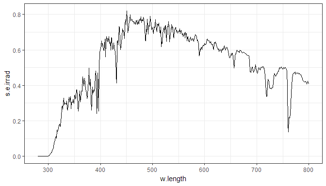

```r
ggplot(sun.spct) + geom_line()
```

It is possible to the defaults by means of `+` and `aes()` as shown below.

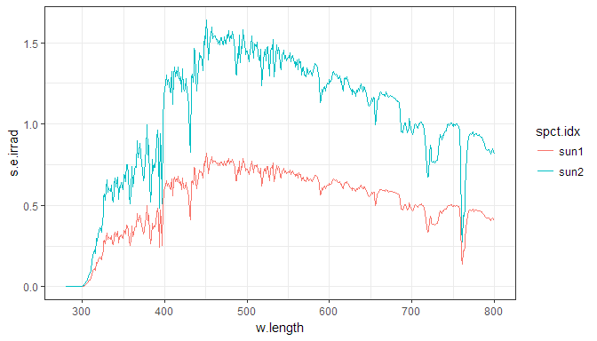

```r
ggplot(two_suns.spct) + aes(color = spct.idx) + geom_line()
```

If a mapping is supplied directly through `ggplot`, $x$ and $y$ should be included.

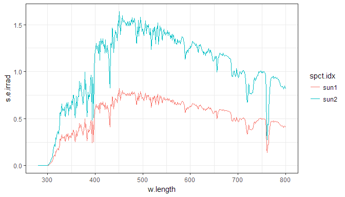

```r
ggplot(two_suns.spct, aes(w.length, s.e.irrad, color = spct.idx)) + geom_line()
```

In the case of `ggplot.source_spct()` an additional parameter allows setting the type of units to use in the plot. This not only sets a suitable `aes()` for $y$ but also if needed converts the spectral data. The two possible values are `"energy"` and `"photon"` and the default, depends on option `photobiology.radiation.unit`.

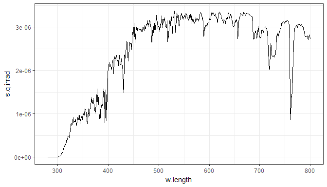

```r
ggplot(sun.spct, unit.out = "photon") + geom_line()
```

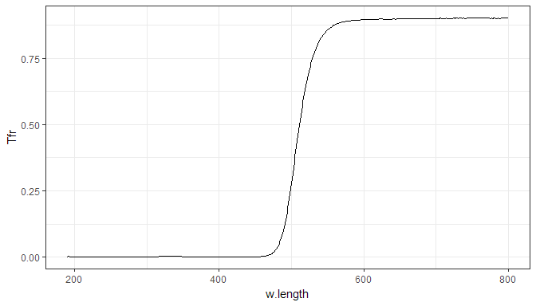

```r
ggplot(yellow_gel.spct) + geom_line()
```

In the case of `ggplot.filter_spct()` the additional parameter is called `plot.qty` and allows choosing between `"transmittance"` and `"absorbance"`.

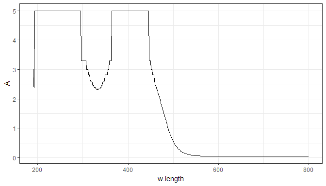

```r
ggplot(yellow_gel.spct, plot.qty = "absorbance") + geom_line()
```

The names of the additional parameters are consistent with those by method `plot()` in this package and in the now deprecated package `photobiologygg`.

## Scales

### Wavelength

Currently only an x-scale function suitable for wavelengths in nanometres is defined in package ‘ggspectra’.

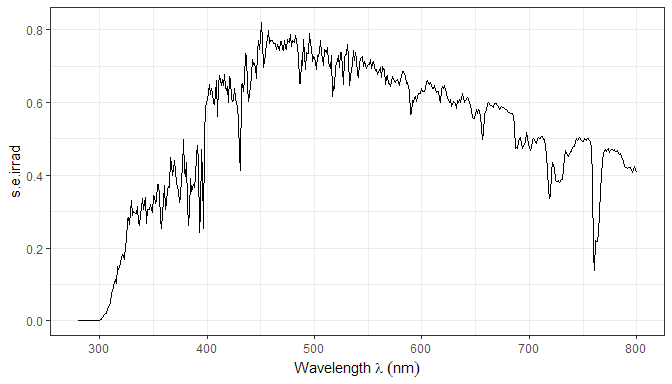

```r
ggplot(sun.spct) +
  geom_line() +
  scale_x_wl_continuous()
```

Functions for automating the addition of secundary axes are also defined.

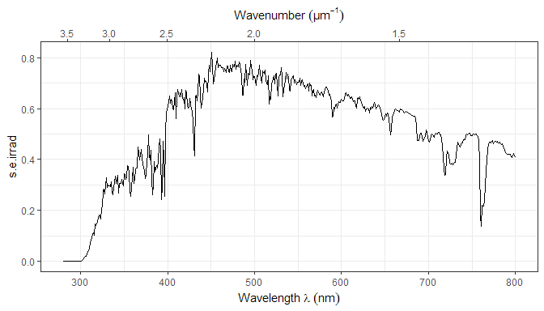

```r
ggplot(sun.spct) +
  geom_line() +
  scale_x_wl_continuous(sec.axis = sec_axis_w_number())
```

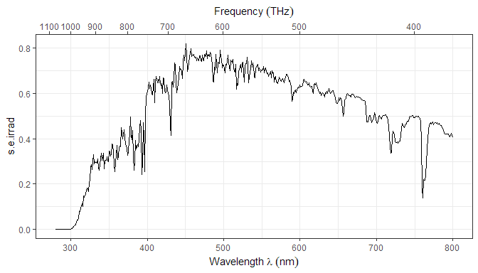

```r
ggplot(sun.spct) +
  geom_line() +
  scale_x_wl_continuous(sec.axis = sec_axis_w_frequency())
```

It is possible to set a different SI scaling factor for the units.

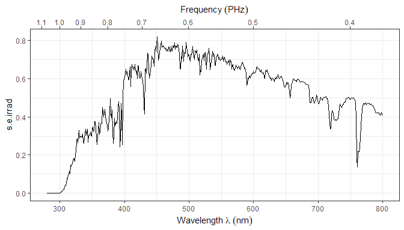

```r
ggplot(sun.spct) +
  geom_line() +
  scale_x_wl_continuous(sec.axis = sec_axis_w_frequency(15))
```

It is possible to set a non-SI scaling factor for the units.

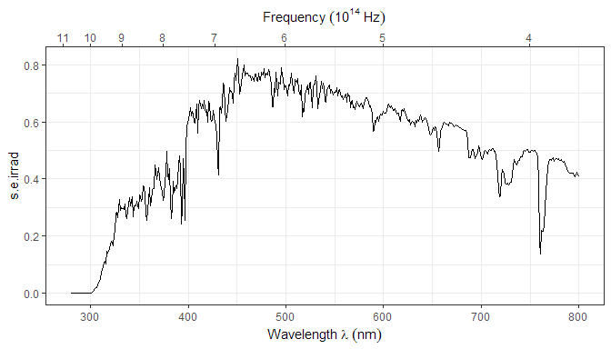

```r
ggplot(sun.spct) +
  geom_line() +
  scale_x_wl_continuous(sec.axis = sec_axis_w_frequency(14))
```

It is possible find the largest valid SI-scaling factor that is smaller or equal to and arbitrary power of 10.

```r
nearest_SI_exponent(14)
```

```
## [1] 12
```

### Raw counts

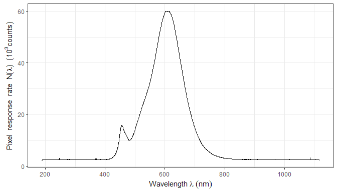

```r
ggplot(white_led.raw_spct) +
  geom_line() +
  scale_x_wl_continuous() +
  scale_y_counts_continuous()
```

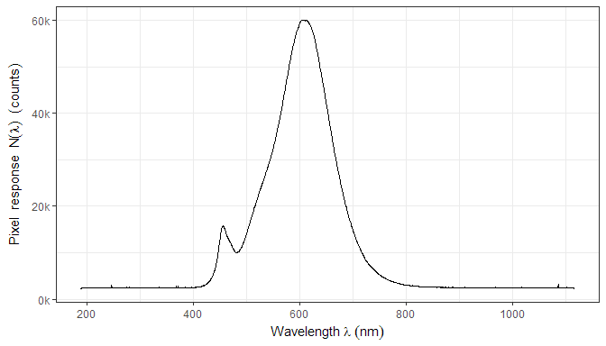

```r
ggplot(white_led.raw_spct) +
  geom_line() +
  scale_x_wl_continuous() +
  scale_y_counts_tg_continuous()
```

### Counts per second

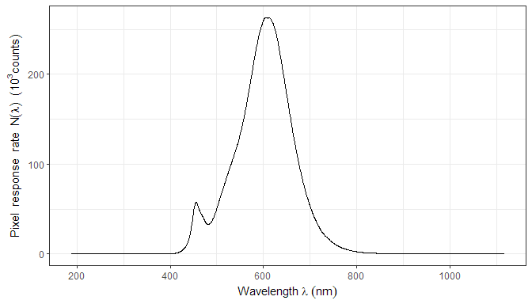

```r
ggplot(white_led.cps_spct) +
  geom_line() +
  scale_x_wl_continuous() +
  scale_y_counts_continuous()
```

### Spectral irradiance

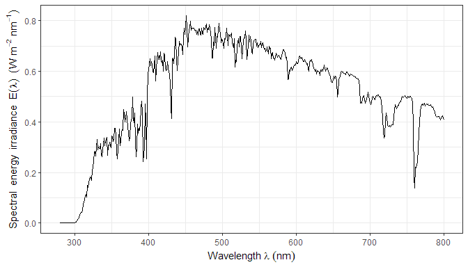

```r
ggplot(sun.spct) +
  geom_line() +
  scale_x_wl_continuous() +
  scale_y_s.e.irrad_continuous()
```

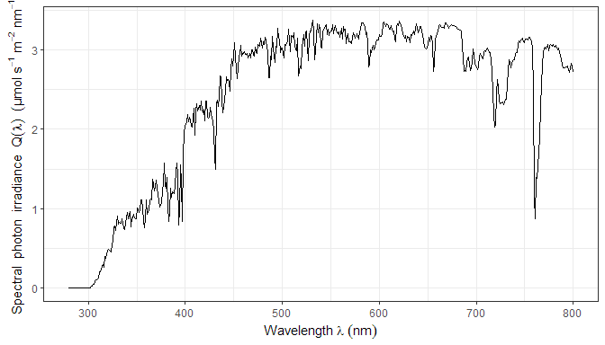

```r
ggplot(sun.spct, unit.out = "photon") +
  geom_line() +
  scale_x_wl_continuous() +
  scale_y_s.q.irrad_continuous()
```

We can change the SI unit multipliers on-the-fly. Beware that these are not data transformations, only the labelling of the axes changes! Consequently summary values will not be affected. We will express the spectral irradiance using milli watts instead of watts and wavelengths in micrometres instead of nanometres.

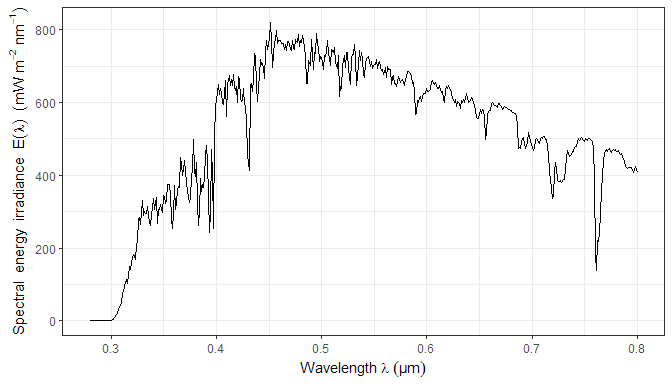

```r
ggplot(sun.spct) +
  geom_line() +
  scale_x_wl_continuous(-6) +
  scale_y_s.e.irrad_continuous(-3)
```

### Response

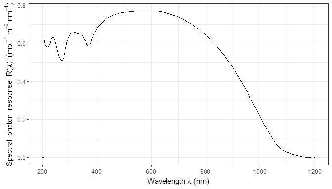

```r
ggplot(ccd.spct, unit.out = "photon") +
  geom_line() +
  scale_x_wl_continuous() +
  scale_y_s.q.response_continuous()
```

### Transmittance

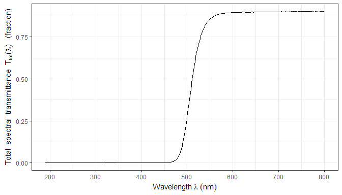

```r
ggplot(yellow_gel.spct) +
  geom_line() +
  scale_x_wl_continuous() +
  scale_y_Tfr_total_continuous()
```

### Absorbance

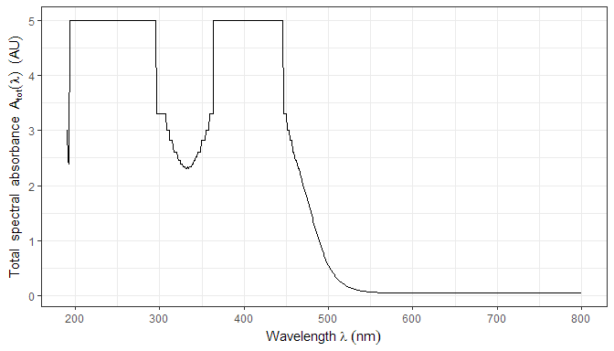

```r
ggplot(yellow_gel.spct, plot.qty = "absorbance") +
  geom_line() +
  scale_x_wl_continuous() +
  scale_y_A_total_continuous()
```

### Reflectance

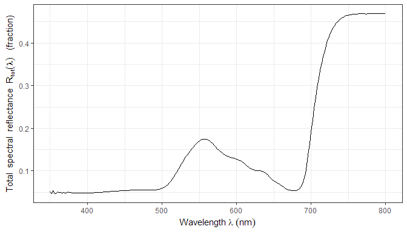

```r
ggplot(green_leaf.spct) +
  geom_line() +
  scale_x_wl_continuous() +
  scale_y_Rfr_total_continuous()
```

## Stats

Several `ggplot` stats are defined by this package. All of them target light spectra, as they expect $x$ to represent wavelengths expressed in nanometres. However, they should behave correctly as long as this is true, with any `ggplot` object, based on any data format acceptable to `ggplot`. The name of the original variable is irrelevant, and it is the user responsibility to supply the correct variables through `aes()`. Of course, when using the spectral classes defined in package `photobiology` the defaults easy this task.

### Peaks and valleys

Four stats are available, they all have the same formal parameters. These stats do not fit peaks, simply search for local maxima and local minima in the data as supplied. Stats `stat_peaks()` and `stat_valleys()` subset the original data while `stat_label_peaks()` and `stat_label_valleys()` only set a boolean flag to mark the local extremes. All these stats set several aesthetics based on calculated values. Not all of these aesthetics are used by the default geom, but they make using other geoms easy. Furthermore text labels are formatted with `sptintf()` and these four stats accept format definitions through parameters `label.fmt`, `x.label.fmt`, and `y.label.fmt`. Both the $x$ and $y$ values at the maxima or minima are returned or flagged. The stats use internally function `photobiology::find_peaks()` and arguments are passed down to it.

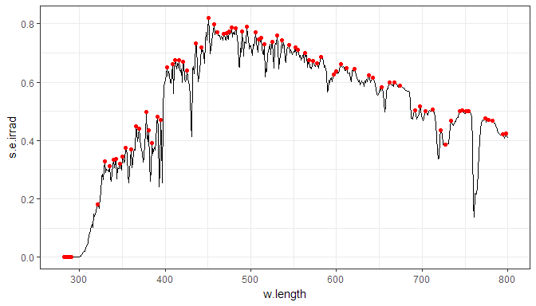

```r
ggplot(sun.spct) + geom_line() + stat_peaks(color = "red")
```

Because of the conversion, the location of maxima and minima when an spectrum is expressed in photon and energy based units may differ. This is expected and not a bug.

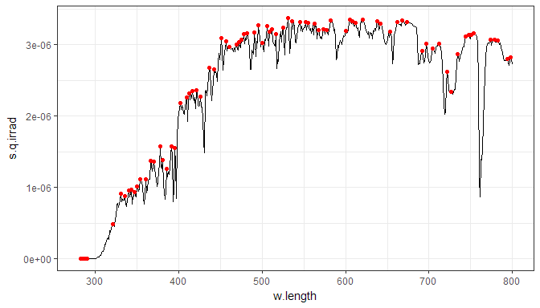

```r
ggplot(sun.spct, unit.out = "photon") + geom_line() + stat_peaks(color = "red")
```

The complement to `stat_peaks()` is `stat_valleys`.

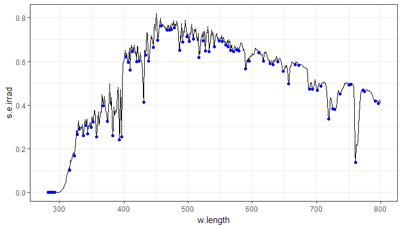

```r
ggplot(sun.spct) + geom_line() + stat_valleys(color = "blue")
```

One of the values calculated and mapped is colour as seen by humans corresponding to the wavelength at the location of peaks and valleys. The colour is mapped to the `fill` aesthetic, so using a ‘filled’ shape results in a colourful plot. The *identity* scale is needed so that the correct colours are displayed using the colour definitions in the calculated data instead of a palette.

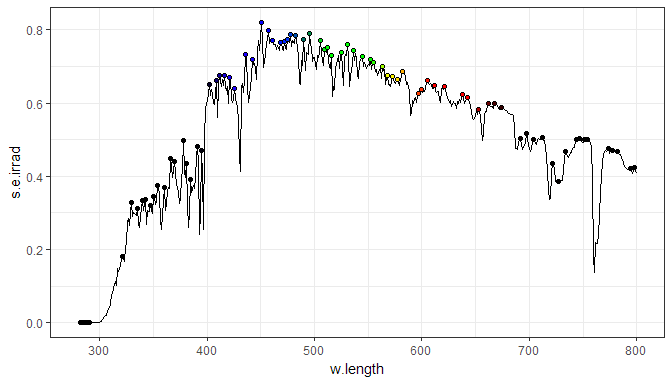

```r
ggplot(sun.spct) + geom_line() +
  stat_peaks(shape = 21, color = "black") + scale_fill_identity()
```

We can use any of the aesthetics affecting the default *geom*, `"point"`, and also with other _geom_s.

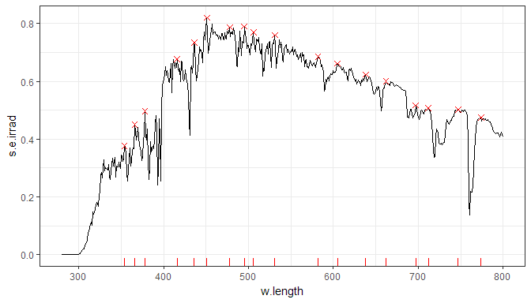

```r
ggplot(sun.spct) + geom_line() +
  stat_peaks(span = 21, shape = 4, color = "red", size = 2) +
  stat_peaks(span = 21, color = "red", geom = "rug", sides = "b")
```

We can use several other *geoms* as needed, demonstrated here with *geom* `"text"`.

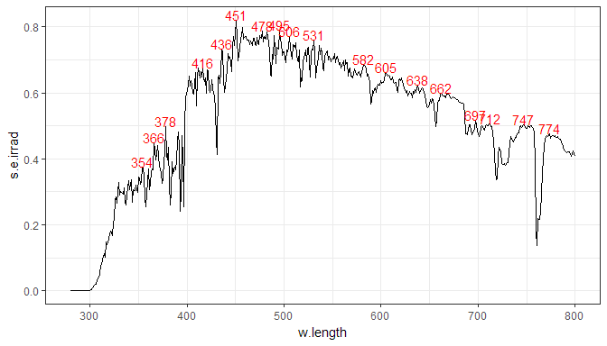

```r
ggplot(sun.spct) + geom_line() +
  stat_peaks(span = 21, geom = "text", color = "red", vjust = "bottom")
```

The same stat can be included more than once in the same plot, using different *geoms*. We here in addition demonstrate the use of several different parameters. The `span` argument determines the number of consecutive observations tested when searching for a local extreme, and it should be an odd integer number. In addition we here demonstrate the use of a *geom* new to `ggplot2` 2.0.0 called `"label"` which again results in colourful labels by default.

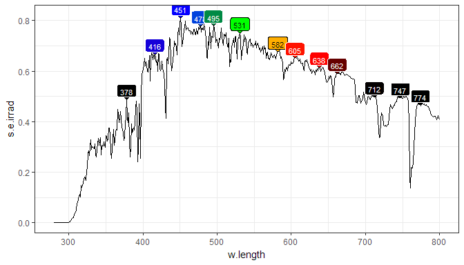

```r
ggplot(sun.spct) + geom_line() +
  stat_peaks(shape = 21, span = 25, size = 2) +
  scale_fill_identity() +
  stat_peaks(aes(color = ..BW.color..),
             geom = "label", span = 25, vjust = "bottom", size = 3) +
  scale_color_identity()
```

To avoid overlap between labels we can use the repulsive geoms from package `ggrepel`. In this case we need to use `stat_label_peaks()`. Repulsion allows the use of larger labels. We also need to expand the $y$ limits to make space for the labels.